# ShrinkageTrees: Bayesian Tree Ensembles for Survival Analysis and Causal Inference

Tijn Jacobs

2026-03-05

## Introduction

**ShrinkageTrees** is an R package that brings Bayesian Additive Regression Trees (BART; Chipman, George & McCulloch, 2010) to **survival analysis** and **causal inference**, with a particular focus on high-dimensional data.

The package implements BART-based models for **right-censored** and **interval-censored** survival outcomes using an accelerated failure time (AFT) formulation. Censored event times are handled through Bayesian data augmentation in the Gibbs sampler, enabling full posterior inference without proportional-hazards assumptions. For causal inference, the package provides Bayesian Causal Forests (BCF; Hahn, Murray & Carvalho, 2020), which decompose the outcome into a prognostic function $\mu(\mathbf{x})$ and a treatment-effect function $\tau(\mathbf{x})$, each estimated by a separate tree ensemble. This two-forest structure supports estimation of heterogeneous treatment effects (CATEs) and the average treatment effect (ATE).

A key feature is the availability of multiple **regularisation strategies** that can be freely combined within a single model:

- **Classical BART priors** on the tree structure and leaf parameters.
- **Dirichlet splitting priors** (DART; Linero, 2018) for structural variable selection.
- **Horseshoe shrinkage on the leaf step heights** (Jacobs, van Wieringen & van der Pas, 2025) — a global–local prior that aggressively shrinks uninformative leaves toward zero while preserving strong signals. This is the main methodological novelty implemented in the package.
- **Half-Cauchy shrinkage** — a lighter-weight alternative that provides local shrinkage without a global scale parameter.

### Package map

| Function | Task | Prior |
| --- | --- | --- |
| `HorseTrees()` | Prediction (continuous / binary / survival*) | Horseshoe |
| `ShrinkageTrees()` | Prediction — flexible prior choice* | Horseshoe, DART, BART, … |
| `SurvivalBART()` | Survival prediction* | Classical BART |
| `SurvivalDART()` | Sparse survival prediction* | DART (Dirichlet) |
| `SurvivalBCF()` | Causal survival inference* | BCF (classical) |
| `SurvivalShrinkageBCF()` | Sparse causal survival inference* | BCF + DART |
| `CausalHorseForest()` | Causal inference (all outcomes*) | Horseshoe |
| `CausalShrinkageForest()` | Causal inference — flexible prior* | Horseshoe, DART, BART, … |

* All survival functions support both right-censored and interval-censored outcomes.

All model-fitting functions return an S3 object with consistent `print()`, `summary()`, `predict()`, and `plot()` methods.

## Key Concepts

Before diving into examples, we clarify a few concepts that appear throughout the package interface.

### Outcome types and the `timescale` parameter

Every model-fitting function accepts an `outcome_type` argument:

- `"continuous"` — standard regression (default for most functions).
- `"binary"` — probit BART for binary outcomes (0/1).
- `"right-censored"` — accelerated failure time model for survival data. The outcome `y` contains (possibly censored) follow-up times, and the `status` vector indicates events (1) vs. censored observations (0).
- `"interval-censored"` — AFT model for interval-censored survival data. Instead of `y` and `status`, provide `left_time` and `right_time` vectors specifying the lower and upper bounds of the observation window for each individual. Three cases are distinguished:
  - **Exact events**: `left_time == right_time` (event observed exactly).
  - **Interval-censored**: `left_time < right_time` with finite `right_time` (event occurred somewhere in the interval).
  - **Right-censored**: `right_time = Inf` (event not yet observed).

  This convention follows `survival::Surv(type = "interval2")`.

For survival outcomes, the `timescale` argument controls how the package treats the times:

- `timescale = "time"` (default): the supplied values are on the **original time scale** (positive numbers). The package internally applies a log-transform, i.e. models $\log(T) = f(\mathbf{x}) + \varepsilon$. Predictions from `summary()` and `predict()` are back-transformed to the time scale automatically.
- `timescale = "log"`: the supplied values are **already log-transformed**. No further transformation is applied. Predictions stay on the log scale.

In most applications you should use `timescale = "time"` and pass the raw survival times directly.

### Shrinkage priors on the step heights

In a BART ensemble each tree contributes a step height (leaf parameter) to the overall prediction. Classical BART assigns these step heights a fixed-variance Gaussian prior, which regularises all leaves equally. In high-dimensional settings, stronger and more adaptive regularisation is desirable. **ShrinkageTrees** implements two shrinkage priors that are placed directly on the step heights via a scale mixture of normals:

$$h_\ell \mid \lambda_\ell, \tau, \omega \sim
\mathcal{N}(0,\; \omega\, \lambda_\ell^2\, \tau^2).$$

Here $\tau$ is a **global** shrinkage parameter shared across all leaves, $\lambda_\ell$ is a **local** scale specific to leaf $\ell$, and $\omega$ is a fixed scaling constant. The two currently implemented instantiations are:

- **Horseshoe** (`prior_type = "horseshoe"`). Both $\lambda_\ell$ and $\tau$ receive independent half-Cauchy priors. The heavy tails of the half-Cauchy allow individual leaves to escape shrinkage when the data support a strong effect, while the global parameter $\tau$ pulls the bulk of the estimates toward zero. This is the default prior in `HorseTrees()` and `CausalHorseForest()`.
- **Half-Cauchy** (`prior_type = "half-cauchy"`). Only the local scales $\lambda_\ell$ receive a half-Cauchy prior; there is no global shrinkage parameter. This provides per-leaf adaptivity without the additional pooling across the ensemble.

A forest-wide variant of the horseshoe (`prior_type = "horseshoe_fw"`) shares a single global $\tau$ across all trees in the forest rather than one per tree. These priors can be selected in `ShrinkageTrees()` and `CausalShrinkageForest()` via the `prior_type` argument, and can be combined with DART’s Dirichlet splitting prior for simultaneous structural and parametric regularisation.

### Hyperparameter selection

The two most important hyperparameters are `local_hp` and `global_hp`. These control the horseshoe prior on the step heights (leaf parameters):

$$\mu_{jl} \mid \lambda_{jl}, \tau_j \sim \mathcal{N}(0, \lambda_{jl}^2
\tau_j^2),
\qquad \lambda_{jl} \sim \text{C}^+(0, \texttt{local\_hp}),
\qquad \tau_j \sim \text{C}^+(0, \texttt{global\_hp}),$$

where $\text{C}^+$ denotes the half-Cauchy distribution. Smaller values produce stronger shrinkage toward zero; larger values allow more variation.

**`HorseTrees()` and `CausalHorseForest()`** provide a convenience parameter `k` that sets both scales automatically: `local_hp = global_hp = k / sqrt(number_of_trees)`. The default `k = 0.1` works well in many settings and is a good starting point.

**`ShrinkageTrees()` and `CausalShrinkageForest()`** expose `local_hp` and `global_hp` directly (no `k`). A common rule of thumb is:

- `local_hp = k / sqrt(number_of_trees)` with `k` in [0.05, 0.5].
- `global_hp = local_hp` (symmetric) or a larger value if you want less overall shrinkage.

The **survival functions** (`SurvivalBART`, `SurvivalDART`) use `k` to calibrate the standard BART leaf prior: `local_hp = range(log(y)) / (2 * k * sqrt(number_of_trees))`. The default `k = 2` follows Chipman et al. (2010).

### The `store_posterior_sample` flag

When `store_posterior_sample = TRUE`, the fitted object stores the full $N_\text{post} \times n$ matrix of posterior draws for predictions. This is needed for:

- `predict()` on new data (it re-runs the sampler internally, so posterior samples are always produced);
- `plot(fit, type = "ate")` and `plot(fit, type = "cate")`, which require the full posterior distribution;
- `plot(fit, type = "survival")` — full posterior credible bands over both $\mu_i$ and $\sigma$ (without samples, only sigma-uncertainty bands are available);
- any custom posterior analysis (e.g. computing posterior credible intervals for individual predictions).

### Treatment coding (`treatment_coding`)

All causal model functions — `CausalHorseForest()`, `CausalShrinkageForest()`, `SurvivalBCF()`, and `SurvivalShrinkageBCF()` — decompose the outcome as
$$Y_i = \mu(\mathbf{x}_i) + b_i \cdot \tau(\mathbf{x}_i) + \varepsilon_i,$$
where $b_i$ is a scalar that depends on the treatment assignment $Z_i$. The `treatment_coding` argument controls how $b_i$ is defined. Four options are available:

**`"centered"`** (default). $b_i = Z_i - 1/2$, so that $b_i \in \{-1/2,\; 1/2\}$. This is the original BCF parameterisation.

**`"binary"`**. $b_i = Z_i$, so that $b_i \in \{0,\; 1\}$. Standard binary coding; the treatment forest captures the full effect of treatment on the treated.

**`"adaptive"`**. $b_i = Z_i - \hat{e}(\mathbf{x}_i)$, where $\hat{e}(\mathbf{x}_i)$ is the estimated propensity score. This follows Hahn, Murray & Carvalho (2020) and is the coding used in the `bcf` R package. When using this option, a `propensity` vector must be supplied.

**`"invariant"`**. Parameter-expanded (invariant) treatment coding. The coding parameters $b_0$ and $b_1$ are assigned $N(0,\; 1/2)$ priors and estimated within the Gibbs sampler via conjugate normal updates:
$$Y_i = \mu(\mathbf{x}_i) + b_{Z_i} \cdot \tilde{\tau}(\mathbf{x}_i) +
\varepsilon_i,
\qquad b_0,\; b_1 \sim N(0,\; 1/2).$$
The treatment effect is $\tau(\mathbf{x}_i) = (b_1 - b_0) \cdot \tilde{\tau}(\mathbf{x}_i)$, and the posterior draws of $b_0$ and $b_1$ are returned in the fitted object. This parameterisation is invariant to the coding of the treatment indicator (Hahn et al., 2020, Section 5.2).

The examples below illustrate each option on a simple continuous-outcome causal model.

```r
set.seed(50)
n_tc <- 60;  p_tc <- 5
X_tc <- matrix(rnorm(n_tc * p_tc), n_tc, p_tc)
W_tc <- rbinom(n_tc, 1, 0.5)
tau_tc <- 1.5 * (X_tc[, 1] > 0)
y_tc <- X_tc[, 1] + W_tc * tau_tc + rnorm(n_tc, sd = 0.5)
```

```r
# Centered (default)
fit_tc_cen <- CausalHorseForest(
  y = y_tc,
  X_train_control = X_tc, X_train_treat = X_tc,
  treatment_indicator_train = W_tc,
  treatment_coding = "centered",
  number_of_trees = 5, N_post = 50, N_burn = 25,
  store_posterior_sample = TRUE, verbose = FALSE
)
cat("Centered — ATE:",
    round(mean(fit_tc_cen$train_predictions_treat), 3), "\n")
```

```
#> Centered — ATE: 0.238
```

```r
# Binary
fit_tc_bin <- CausalHorseForest(
  y = y_tc,
  X_train_control = X_tc, X_train_treat = X_tc,
  treatment_indicator_train = W_tc,
  treatment_coding = "binary",
  number_of_trees = 5, N_post = 50, N_burn = 25,
  store_posterior_sample = TRUE, verbose = FALSE
)
cat("Binary — ATE:",
    round(mean(fit_tc_bin$train_predictions_treat), 3), "\n")
```

```
#> Binary — ATE: 0.521
```

```r
# Adaptive (requires propensity scores)
ps_tc <- pnorm(0.3 * X_tc[, 1])   # simple propensity model for illustration

fit_tc_ada <- CausalHorseForest(
  y = y_tc,
  X_train_control = X_tc, X_train_treat = X_tc,
  treatment_indicator_train = W_tc,
  treatment_coding = "adaptive",
  propensity = ps_tc,
  number_of_trees = 5, N_post = 50, N_burn = 25,
  store_posterior_sample = TRUE, verbose = FALSE
)
cat("Adaptive — ATE:",
    round(mean(fit_tc_ada$train_predictions_treat), 3), "\n")
```

```
#> Adaptive — ATE: 0.154
```

```r
# Invariant (parameter-expanded)
fit_tc_inv <- CausalHorseForest(
  y = y_tc,
  X_train_control = X_tc, X_train_treat = X_tc,
  treatment_indicator_train = W_tc,
  treatment_coding = "invariant",
  number_of_trees = 5, N_post = 50, N_burn = 25,
  store_posterior_sample = TRUE, verbose = FALSE
)
cat("Invariant — ATE:",
    round(mean(fit_tc_inv$train_predictions_treat), 3), "\n")
```

```
#> Invariant — ATE: 0.232
```

```r
# Posterior draws of b0 and b1 are stored in the fitted object
cat("b0 posterior mean:", round(mean(fit_tc_inv$b0), 3), "\n")
```

```
#> b0 posterior mean: 0.068
```

```r
cat("b1 posterior mean:", round(mean(fit_tc_inv$b1), 3), "\n")
```

```
#> b1 posterior mean: 0.153
```

The survival functions inherit `treatment_coding` support. For example, `SurvivalBCF(..., treatment_coding = "invariant")` works out of the box.

## Included Datasets

The package ships with two TCGA datasets for high-dimensional survival analysis and causal inference:

### The PDAC Dataset

The `pdac` dataset contains overall survival times, a binary treatment indicator (radiation therapy vs. control), clinical covariates, and expression values of approximately 3,000 genes selected by median absolute deviation.

```r
library(ShrinkageTrees)
data("pdac")

# Dimensions and column overview
cat("Patients:", nrow(pdac), "\n")
```

```
#> Patients: 130
```

```r
cat("Columns :", ncol(pdac), "\n")
```

```
#> Columns : 3032
```

```r
cat("Clinical columns:", paste(names(pdac)[1:13], collapse = ", "), "\n")
```

```
#> Clinical columns: time, status, treatment, age, sex, grade, tumor.cellularity, tumor.purity, absolute.purity, moffitt.cluster, meth.leukocyte.percent, meth.purity.mode, stage
```

```r
cat("Survival: time (months), censoring rate =",
    round(1 - mean(pdac$status), 2), "\n")
```

```
#> Survival: time (months), censoring rate = 0.47
```

```r
cat("Treatment: radiation =", sum(pdac$treatment),
    "/ control =", sum(1 - pdac$treatment), "\n")
```

```
#> Treatment: radiation = 36 / control = 94
```

We separate the outcome, treatment, and covariate matrix for the analyses below.

```r
time      <- pdac$time
status    <- pdac$status
treatment <- pdac$treatment
X         <- as.matrix(pdac[, !(names(pdac) %in% c("time", "status", "treatment"))])
```

## Prediction Models

This section demonstrates the single-forest models in **ShrinkageTrees**. These models estimate a single function $f(\mathbf{x})$ of the covariates, applicable to continuous, binary, and survival outcomes. We begin with a binary-outcome example that will also serve as the propensity score model for the causal analyses later.

### HorseTrees — binary outcome (propensity scores)

Before fitting causal models we estimate propensity scores $\hat{e}(\mathbf{x}) = P(W=1 \mid \mathbf{x})$ using `HorseTrees()` with a binary outcome. The probit link is used internally: predictions are on the latent Gaussian scale and can be converted to probabilities with `pnorm()`.

The code block below uses reduced MCMC settings for illustration. A real analysis would use `N_post = 5000, N_burn = 5000`.

```r
ps_fit <- HorseTrees(
  y            = treatment,
  X_train      = X,
  outcome_type = "binary",
  k            = 0.1,
  N_post       = 5000,
  N_burn       = 5000,
  verbose      = FALSE
)

propensity <- pnorm(ps_fit$train_predictions)
```

For the remainder of this vignette we use a short synthetic run to keep build time low.

```r
set.seed(1)
n <- 80;  p <- 10
X_syn  <- matrix(rnorm(n * p), n, p)
W_syn  <- rbinom(n, 1, pnorm(0.8 * X_syn[, 1]))

ps_fit <- HorseTrees(
  y            = W_syn,
  X_train      = X_syn,
  outcome_type = "binary",
  number_of_trees = 5,
  k            = 0.5,
  N_post       = 50,
  N_burn       = 25,
  verbose      = FALSE
)

propensity_syn <- pnorm(ps_fit$train_predictions)
cat("Propensity scores — range: [",
    round(range(propensity_syn), 3), "]\n")
```

```
#> Propensity scores — range: [ 0.469 0.539 ]
```

### HorseTrees — survival outcome

`HorseTrees()` handles right-censored data via an AFT model. Pass `outcome_type = "right-censored"` and provide the `status` vector (1 = event, 0 = censored). When `timescale = "time"` (the default), the package log-transforms survival times internally and returns predictions on the log scale (see *Key Concepts* above).

```r
set.seed(2)
log_T <- X_syn[, 1] + rnorm(n)
C     <- rexp(n, 0.5)
y_syn   <- pmin(exp(log_T), C)
d_syn   <- as.integer(exp(log_T) <= C)

ht_surv <- HorseTrees(
  y               = y_syn,
  status          = d_syn,
  X_train         = X_syn,
  outcome_type    = "right-censored",
  timescale       = "time",
  number_of_trees = 5,
  N_post          = 50,
  N_burn          = 25,
  store_posterior_sample = TRUE,
  verbose         = FALSE
)

cat("Posterior mean log-time (first 5 obs):",
    round(ht_surv$train_predictions[1:5], 3), "\n")
```

```
#> Posterior mean log-time (first 5 obs): 1.204 1.319 1.354 1.389 1.247
```

```r
cat("Posterior sigma — mean:",
    round(mean(ht_surv$sigma), 3), "\n")
```

```
#> Posterior sigma — mean: 0.981
```

### HorseTrees — interval-censored outcome

When event times are not observed exactly but known to lie within an interval, the package supports **interval censoring**. Instead of providing `y` and `status`, pass `left_time` and `right_time` with `outcome_type = "interval-censored"`.

The three censoring types are encoded as follows:

- **Exact event**: `left_time[i] == right_time[i]`
- **Interval-censored**: `left_time[i] < right_time[i]` (both finite)
- **Right-censored**: `right_time[i] = Inf`

This convention matches `survival::Surv(type = "interval2")`.

```r
set.seed(20)

# Generate true event times
true_T <- rexp(n, rate = exp(-0.5 * X_syn[, 1]))

# Create interval-censored observations
left_syn  <- true_T * runif(n, 0.5, 1.0)
right_syn <- true_T * runif(n, 1.0, 1.5)

# Mark some as exact observations and some as right-censored
exact_idx <- sample(n, 25)
left_syn[exact_idx]  <- true_T[exact_idx]
right_syn[exact_idx] <- true_T[exact_idx]

rc_idx <- sample(setdiff(seq_len(n), exact_idx), 15)
right_syn[rc_idx] <- Inf

cat("Exact events:", sum(left_syn == right_syn), "\n")
```

```
#> Exact events: 25
```

```r
cat("Interval-censored:", sum(left_syn < right_syn & is.finite(right_syn)), "\n")
```

```
#> Interval-censored: 40
```

```r
cat("Right-censored:", sum(!is.finite(right_syn)), "\n")
```

```
#> Right-censored: 15
```

```r
ht_ic <- HorseTrees(
  left_time       = left_syn,
  right_time      = right_syn,
  X_train         = X_syn,
  outcome_type    = "interval-censored",
  timescale       = "time",
  number_of_trees = 5,
  N_post          = 50,
  N_burn          = 25,
  store_posterior_sample = TRUE,
  verbose         = FALSE
)

cat("Posterior mean log-time (first 5 obs):",
    round(ht_ic$train_predictions[1:5], 3), "\n")
```

```
#> Posterior mean log-time (first 5 obs): 0.666 0.698 0.596 0.785 0.726
```

```r
cat("Posterior sigma — mean:",
    round(mean(ht_ic$sigma), 3), "\n")
```

```
#> Posterior sigma — mean: 1.016
```

All survival functions (`SurvivalBART`, `SurvivalDART`, `SurvivalBCF`, `SurvivalShrinkageBCF`) and the general-purpose functions (`ShrinkageTrees`, `CausalShrinkageForest`, `CausalHorseForest`) accept `left_time` and `right_time` in the same way. For example, using `SurvivalBART`:

```r
set.seed(21)
fit_sbart_ic <- SurvivalBART(
  left_time       = left_syn,
  right_time      = right_syn,
  X_train         = X_syn,
  number_of_trees = 5,
  N_post          = 50,
  N_burn          = 25,
  verbose         = FALSE
)

cat("SurvivalBART (IC) class:", class(fit_sbart_ic), "\n")
```

```
#> SurvivalBART (IC) class: ShrinkageTrees
```

### ShrinkageTrees — flexible prior choice

While `HorseTrees()` fixes the prior to the horseshoe, the more general `ShrinkageTrees()` function exposes the `prior_type` argument, allowing the user to select among all implemented regularisation strategies. Available options are `"horseshoe"`, `"horseshoe_fw"` (forest-wide), `"half-cauchy"`, `"standard"` (classical BART), and `"dirichlet"` (DART). Below we compare the per-tree horseshoe and the forest-wide horseshoe on a continuous outcome.

```r
set.seed(3)
y_cont <- X_syn[, 1] + 0.5 * X_syn[, 2] + rnorm(n)

# Horseshoe prior (default for HorseTrees)
fit_hs <- ShrinkageTrees(
  y               = y_cont,
  X_train         = X_syn,
  outcome_type    = "continuous",
  prior_type      = "horseshoe",
  local_hp        = 0.1 / sqrt(5),
  global_hp       = 0.1 / sqrt(5),
  number_of_trees = 5,
  N_post          = 50,
  N_burn          = 25,
  verbose         = FALSE
)

# Forest-wide horseshoe (horseshoe_fw)
fit_fw <- ShrinkageTrees(
  y               = y_cont,
  X_train         = X_syn,
  outcome_type    = "continuous",
  prior_type      = "horseshoe_fw",
  local_hp        = 0.1 / sqrt(5),
  global_hp       = 0.1 / sqrt(5),
  number_of_trees = 5,
  N_post          = 50,
  N_burn          = 25,
  verbose         = FALSE
)

cat("Horseshoe   — train RMSE:",
    round(sqrt(mean((fit_hs$train_predictions - y_cont)^2)), 3), "\n")
```

```
#> Horseshoe   — train RMSE: 1.217
```

```r
cat("Horseshoe FW— train RMSE:",
    round(sqrt(mean((fit_fw$train_predictions - y_cont)^2)), 3), "\n")
```

```
#> Horseshoe FW— train RMSE: 1.23
```

### SurvivalBART and SurvivalDART

`SurvivalBART()` and `SurvivalDART()` fit classical BART and DART models for right-censored survival data under the AFT formulation. They calibrate prior hyperparameters automatically from the data range, providing a simple interface when horseshoe shrinkage is not needed.

```r
set.seed(4)

# SurvivalBART: classical BART prior, AFT likelihood
fit_sbart <- SurvivalBART(
  time            = y_syn,
  status          = d_syn,
  X_train         = X_syn,
  number_of_trees = 5,
  k               = 2.0,
  N_post          = 50,
  N_burn          = 25,
  verbose         = FALSE
)

# SurvivalDART: Dirichlet (DART) splitting prior
fit_sdart <- SurvivalDART(
  time            = y_syn,
  status          = d_syn,
  X_train         = X_syn,
  number_of_trees = 5,
  k               = 2.0,
  N_post          = 50,
  N_burn          = 25,
  verbose         = FALSE
)

cat("SurvivalBART  class:", class(fit_sbart), "\n")
```

```
#> SurvivalBART  class: ShrinkageTrees
```

```r
cat("SurvivalDART  class:", class(fit_sdart), "\n")
```

```
#> SurvivalDART  class: ShrinkageTrees
```

## High-Dimensional Survival Analysis

A key motivation for horseshoe shrinkage and the Dirichlet (DART) sparsity prior is their behaviour in the **$p \gg n$ regime**: many covariates are available but only a small subset drives the outcome. Classical BART may struggle here because the standard Gaussian leaf prior is non-sparse and does not concentrate on a small number of predictors.

We illustrate both priors on a sparse AFT simulation: $n = 60$ observations, $p = 200$ predictors, and only three active predictors.

```r
set.seed(20)
n_hd <- 60;  p_hd <- 200
X_hd <- matrix(rnorm(n_hd * p_hd), n_hd, p_hd)

# True log-survival depends only on predictors 1, 2, and 3
log_T_hd <- 1.5 * X_hd[, 1] - 1.0 * X_hd[, 2] + 0.5 * X_hd[, 3] + rnorm(n_hd)
C_hd     <- rexp(n_hd, rate = 0.5)
y_hd     <- pmin(exp(log_T_hd), C_hd)
d_hd     <- as.integer(exp(log_T_hd) <= C_hd)

cat("n =", n_hd, "| p =", p_hd,
    "| active predictors = 3",
    "| censoring rate =", round(1 - mean(d_hd), 2), "\n")
```

```
#> n = 60 | p = 200 | active predictors = 3 | censoring rate = 0.4
```

**ShrinkageTrees (horseshoe)** places global–local shrinkage on the step heights of every leaf, automatically regularising all 200 predictors toward zero while preserving the signal in the three active ones.

```r
set.seed(21)
fit_hd_hs <- ShrinkageTrees(
  y               = y_hd,
  status          = d_hd,
  X_train         = X_hd,
  outcome_type    = "right-censored",
  prior_type      = "horseshoe",
  local_hp        = 0.1 / sqrt(10),
  global_hp       = 0.1 / sqrt(10),
  number_of_trees = 10,
  N_post          = 50,
  N_burn          = 25,
  verbose         = FALSE
)
```

```r
set.seed(22)
fit_hd_dart <- SurvivalDART(
  time            = y_hd,
  status          = d_hd,
  X_train         = X_hd,
  number_of_trees = 10,
  rho_dirichlet   = 3,
  N_post          = 50,
  N_burn          = 25,
  verbose         = FALSE
)
```

Both models run without error in the $p > n$ regime. We compare their posterior mean predictions in log-time against the latent true values used to generate the data.

```r
rmse_hs   <- sqrt(mean((fit_hd_hs$train_predictions  - log_T_hd)^2))
rmse_dart <- sqrt(mean((fit_hd_dart$train_predictions - log_T_hd)^2))

cat(sprintf("%-18s  train RMSE (log-time): %.3f\n", "Horseshoe", rmse_hs))
```

```
#> Horseshoe           train RMSE (log-time): 2.530
```

```r
cat(sprintf("%-18s  train RMSE (log-time): %.3f\n", "DART",      rmse_dart))
```

```
#> DART                train RMSE (log-time): 2.402
```

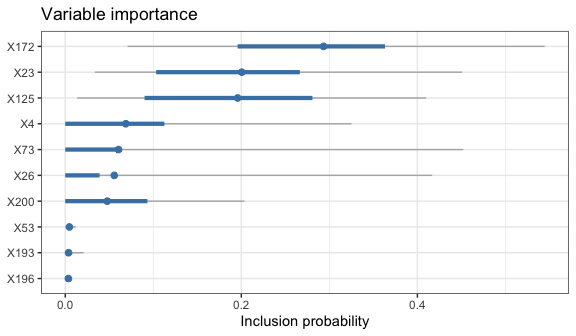

```r
plot(fit_hd_dart, type = "vi", n_vi = 10)
```

## Causal Forest Models

For causal inference, **ShrinkageTrees** provides Bayesian Causal Forest (BCF) models that decompose the outcome into a prognostic component and a treatment effect component:
$$Y_i = \mu(\mathbf{x}_i) + W_i \cdot \tau(\mathbf{x}_i) + \varepsilon_i,$$
where $\mu(\cdot)$ is the prognostic (control) function modelled by one tree ensemble, and $\tau(\cdot)$ is the heterogeneous treatment effect modelled by a second ensemble. This two-forest structure allows each component to have its own regularisation, number of trees, and prior — for instance, a standard BART prior for the prognostic forest and horseshoe shrinkage for the treatment effect forest.

The package provides four causal model functions with increasing generality: `SurvivalBCF()` (classical BCF for survival), `SurvivalShrinkageBCF()` (BCF + DART for survival), `CausalHorseForest()` (horseshoe BCF for all outcome types), and `CausalShrinkageForest()` (fully configurable BCF). We illustrate each below on synthetic data with a known treatment effect.

```r
set.seed(5)
tau_true <- 1.5 * (X_syn[, 1] > 0)    # heterogeneous treatment effect
y_causal <- X_syn[, 1] + W_syn * tau_true + rnorm(n, sd = 0.5)
```

### SurvivalBCF — classical BCF for survival

`SurvivalBCF()` fits a BCF model for right-censored survival outcomes using classical BART priors.

```r
# Full analysis (eval=FALSE — use larger MCMC settings in practice)
fit_sbcf <- SurvivalBCF(
  time       = time,
  status     = status,
  X_train    = X,
  treatment  = treatment,
  propensity = propensity,   # from HorseTrees above
  N_post     = 5000,
  N_burn     = 5000,
  verbose    = FALSE
)
```

```r
set.seed(6)
fit_sbcf <- SurvivalBCF(
  time            = y_syn,
  status          = d_syn,
  X_train         = X_syn,
  treatment       = W_syn,
  number_of_trees_control = 5,
  number_of_trees_treat   = 5,
  N_post          = 50,
  N_burn          = 25,
  verbose         = FALSE
)
cat("SurvivalBCF class:", class(fit_sbcf), "\n")
```

```
#> SurvivalBCF class: CausalShrinkageForest
```

```r
cat("ATE (posterior mean):",
    round(mean(fit_sbcf$train_predictions_treat), 3), "\n")
```

```
#> ATE (posterior mean): 1.475
```

### SurvivalShrinkageBCF — sparse causal survival forest

`SurvivalShrinkageBCF()` extends BCF with a Dirichlet splitting prior on both forests, inducing sparsity in high-dimensional settings.

```r
set.seed(7)
fit_ssbcf <- SurvivalShrinkageBCF(
  time            = y_syn,
  status          = d_syn,
  X_train         = X_syn,
  treatment       = W_syn,
  number_of_trees_control = 5,
  number_of_trees_treat   = 5,
  N_post          = 50,
  N_burn          = 25,
  verbose         = FALSE
)
cat("SurvivalShrinkageBCF class:", class(fit_ssbcf), "\n")
```

```
#> SurvivalShrinkageBCF class: CausalShrinkageForest
```

### CausalHorseForest — horseshoe causal forest

`CausalHorseForest()` is the primary novel contribution of this package. It applies horseshoe shrinkage to the leaf parameters of both the prognostic and treatment-effect forests. This enables effective regularisation when many covariates are available but few are truly predictive of heterogeneous treatment effects.

```r
set.seed(8)
fit_chf <- CausalHorseForest(
  y                         = y_causal,
  X_train_control           = X_syn,
  X_train_treat             = X_syn,
  treatment_indicator_train = W_syn,
  outcome_type              = "continuous",
  number_of_trees           = 5,
  N_post                    = 50,
  N_burn                    = 25,
  store_posterior_sample    = TRUE,
  verbose                   = FALSE
)

cat("CausalHorseForest class:", class(fit_chf), "\n")
```

```
#> CausalHorseForest class: CausalShrinkageForest
```

```r
# Posterior mean CATE
cate_mean <- fit_chf$train_predictions_treat
cat("CATE — posterior mean (first 5):",
    round(cate_mean[1:5], 3), "\n")
```

```
#> CATE — posterior mean (first 5): 1.48 1.559 1.504 1.281 1.421
```

```r
# Posterior ATE
ate_samples <- rowMeans(fit_chf$train_predictions_sample_treat)
cat("ATE posterior mean:",
    round(mean(ate_samples), 3),
    "  95% CI: [",
    round(quantile(ate_samples, 0.025), 3), ",",
    round(quantile(ate_samples, 0.975), 3), "]\n")
```

```
#> ATE posterior mean: 1.422   95% CI: [ 0.567 , 2.154 ]
```

The fitted object stores the posterior mean CATE for each training observation in `train_predictions_treat`. When `store_posterior_sample = TRUE`, the full posterior sample matrix is available in `train_predictions_sample_treat`, from which the posterior ATE distribution and credible intervals can be computed as shown above.

You can also supply separate test matrices to obtain out-of-sample CATE predictions.

```r
set.seed(9)
X_test <- matrix(rnorm(20 * p), 20, p)
W_test <- rbinom(20, 1, 0.5)

fit_chf_test <- CausalHorseForest(
  y                         = y_causal,
  X_train_control           = X_syn,
  X_train_treat             = X_syn,
  treatment_indicator_train = W_syn,
  X_test_control            = X_test,
  X_test_treat              = X_test,
  treatment_indicator_test  = W_test,
  outcome_type              = "continuous",
  number_of_trees           = 5,
  N_post                    = 50,
  N_burn                    = 25,
  store_posterior_sample    = TRUE,
  verbose                   = FALSE
)

cat("Test CATE (first 5):",
    round(fit_chf_test$test_predictions_treat[1:5], 3), "\n")
```

```
#> Test CATE (first 5): 1.599 1.503 1.615 1.497 1.5
```

### CausalShrinkageForest — flexible causal priors

`CausalShrinkageForest()` is the most general causal model interface. It allows independent prior choices for the prognostic and treatment effect forests via `prior_type_control` and `prior_type_treat`. For example, one could use a standard BART prior for the prognostic forest (where variable selection is less critical) and horseshoe shrinkage for the treatment forest (where most covariates are expected to be irrelevant for the treatment effect).

```r
set.seed(10)
lh <- 0.1 / sqrt(5)

fit_csf <- CausalShrinkageForest(
  y                         = y_causal,
  X_train_control           = X_syn,
  X_train_treat             = X_syn,
  treatment_indicator_train = W_syn,
  outcome_type              = "continuous",
  prior_type_control        = "horseshoe",
  prior_type_treat          = "horseshoe",
  local_hp_control          = lh,
  global_hp_control         = lh,
  local_hp_treat            = lh,
  global_hp_treat           = lh,
  number_of_trees_control   = 5,
  number_of_trees_treat     = 5,
  N_post                    = 50,
  N_burn                    = 25,
  store_posterior_sample    = TRUE,
  verbose                   = FALSE
)

cat("CausalShrinkageForest class:", class(fit_csf), "\n")
```

```
#> CausalShrinkageForest class: CausalShrinkageForest
```

```r
cat("Acceptance ratio (control):",
    round(fit_csf$acceptance_ratio_control, 3), "\n")
```

```
#> Acceptance ratio (control): 0.348
```

```r
cat("Acceptance ratio (treat)  :",
    round(fit_csf$acceptance_ratio_treat, 3), "\n")
```

```
#> Acceptance ratio (treat)  : 0.248
```

The `horseshoe_fw` prior adds a forest-wide shrinkage parameter that is tracked in the fitted object.

```r
set.seed(11)
fit_fw2 <- CausalShrinkageForest(
  y                         = y_causal,
  X_train_control           = X_syn,
  X_train_treat             = X_syn,
  treatment_indicator_train = W_syn,
  outcome_type              = "continuous",
  prior_type_control        = "horseshoe_fw",
  prior_type_treat          = "horseshoe_fw",
  local_hp_control          = lh,
  global_hp_control         = lh,
  local_hp_treat            = lh,
  global_hp_treat           = lh,
  number_of_trees_control   = 5,
  number_of_trees_treat     = 5,
  N_post                    = 50,
  N_burn                    = 25,
  verbose                   = FALSE
)

cat("Forest-wide shrinkage (control, first 5 draws):\n")
```

```
#> Forest-wide shrinkage (control, first 5 draws):
```

```r
print(round(fit_fw2$forestwide_shrinkage_control[1:5], 4))
```

```
#> [1] 1 1 1 1 1
```

## S3 Methods

All fitted objects — whether from prediction models or causal models — support a consistent set of S3 methods: `print()`, `summary()`, `predict()`, and `plot()`. This section illustrates each method using the models fitted above.

### print()

Calling `print()` (or just typing the object name) displays a concise model summary.

```r
print(fit_chf)
```

```
#>
#> CausalShrinkageForest model
#> ---------------------------
#> Outcome type:         Continuous
#> Training size (n):    80
#> Posterior draws:      50 (burn-in 25)
#> Posterior mean sigma: 0.821
#>
#>                       Control             Treatment
#>                       ------------------- -------------------
#> Prior:                horseshoe           horseshoe
#> Number of trees:      5                   5
#> Number of features:   10                  10
#> Acceptance ratio:     0.428               0.404
```

For causal models the output additionally shows the number of trees in each forest and prior details for both components.

```r
print(fit_csf)
```

```
#>
#> CausalShrinkageForest model
#> ---------------------------
#> Outcome type:         Continuous
#> Training size (n):    80
#> Posterior draws:      50 (burn-in 25)
#> Posterior mean sigma: 0.814
#>
#>                       Control             Treatment
#>                       ------------------- -------------------
#> Prior:                horseshoe           horseshoe
#> Number of trees:      5                   5
#> Number of features:   10                  10
#> Acceptance ratio:     0.348               0.248
```

### summary()

`summary()` returns a structured list and displays a richer description including posterior statistics for $\sigma$, acceptance ratios, and treatment effect estimates.

```r
smry <- summary(fit_hs)
print(smry)
```

```
#>
#> ShrinkageTrees model summary
#> ============================
#> Call: ShrinkageTrees(y = y_cont, X_train = X_syn, outcome_type = "continuous",
#>     number_of_trees = 5, prior_type = "horseshoe", local_hp = 0.1/sqrt(5),
#>     global_hp = 0.1/sqrt(5), N_post = 50, N_burn = 25, verbose = FALSE)
#>
#> Outcome: Continuous | Prior: horseshoe | Trees: 5
#> Data:    n = 80, p = 10 | Draws: 50 (burn-in 25)
#>
#> Posterior sigma:
#>   Mean: 0.987  SD: 0.089  95% CI: [0.851, 1.205]
#>
#> Predictions (posterior mean):
#>   Train: mean = 0.053, sd = 0.053, range = [-0.094, 0.159]
#>   Test:  mean = 0.065, sd = NA, range = [0.065, 0.065]
#>
#> Variable importance (posterior inclusion probability):
#>   X3: 0.164   X9: 0.143   X4: 0.142   X2: 0.132   X8: 0.131   X5: 0.091   X7: 0.084   X6: 0.064   X10: 0.037   X1: 0.011
#>
#> MCMC acceptance ratio: 0.484
#>
#> Convergence diagnostics (coda):
#>   Effective sample size: sigma = 50
```

For causal models the summary includes the posterior ATE with a 95% credible interval (when `store_posterior_sample = TRUE`).

```r
smry_c <- summary(fit_chf)
print(smry_c)
```

```
#>
#> CausalShrinkageForest model summary
#> =====================================
#> Call: CausalHorseForest(y = y_causal, X_train_control = X_syn, X_train_treat = X_syn,
#>     treatment_indicator_train = W_syn, outcome_type = "continuous",
#>     number_of_trees = 5, N_post = 50, N_burn = 25, store_posterior_sample = TRUE,
#>     verbose = FALSE)
#>
#> Outcome: Continuous
#> Prior:   control = horseshoe, treatment = horseshoe
#> Trees:   control = 5, treatment = 5
#> Data:    n = 80, p_control = 10, p_treat = 10 | Draws: 50 (burn-in 25)
#>
#> Treatment effect (CATE):
#>   ATE:     1.4223  95% CI: [0.5669, 2.1542]
#>   CATE SD: 0.1203
#>
#> Prognostic function (mu):
#>   Mean: 0.597  SD: 0.023  Range: [0.542, 0.662]
#>
#> Posterior sigma:
#>   Mean: 0.821  SD: 0.078  95% CI: [0.695, 0.99]
#>
#> Variable importance - control forest (posterior inclusion probability):
#>   X6: 0.195   X3: 0.162   X2: 0.137   X8: 0.119   X10: 0.098   X9: 0.076   X7: 0.073   X5: 0.07   X4: 0.037   X1: 0.033
#>
#> Variable importance - treatment forest (posterior inclusion probability):
#>   X2: 0.177   X6: 0.173   X3: 0.123   X8: 0.11   X9: 0.098   X10: 0.087   X1: 0.086   X5: 0.068   X4: 0.046   X7: 0.032
#>
#> MCMC acceptance ratios: control = 0.428, treatment = 0.404
```

```r
# Access the ATE directly
cat("ATE mean  :", round(smry_c$treatment_effect$ate, 3), "\n")
```

```
#> ATE mean  : 1.422
```

```r
cat("ATE 95% CI: [",
    round(smry_c$treatment_effect$ate_lower, 3), ",",
    round(smry_c$treatment_effect$ate_upper, 3), "]\n")
```

```
#> ATE 95% CI: [ 0.567 , 2.154 ]
```

### predict()

`predict()` computes the posterior predictive distribution on new data. It returns a `ShrinkageTreesPrediction` object with posterior mean and credible-interval vectors.

```r
X_new  <- matrix(rnorm(10 * p), 10, p)

pred <- predict(fit_hs, newdata = X_new)
print(pred)
```

```
#>
#> ShrinkageTrees predictions
#> --------------------------
#> Observations:         10
#> Credible interval:    95%
#> Scale:                fitted value
#>
#>              mean     lower     upper
#>          --------  --------  --------
#>   [  1]     0.046    -0.175     0.286
#>   [  2]     0.068    -0.324     0.304
#>   [  3]     0.049    -0.336     0.427
#>   [  4]     0.010    -0.401     0.257
#>   [  5]     0.090    -0.151     0.351
#>   [  6]     0.058    -0.176     0.293
#>   ... (4 more)
```

```r
# Point estimates and 95% credible intervals
head(data.frame(
  mean  = round(pred$mean,  3),
  lower = round(pred$lower, 3),
  upper = round(pred$upper, 3)
))
```

```
#>    mean  lower upper
#> 1 0.046 -0.175 0.286
#> 2 0.068 -0.324 0.304
#> 3 0.049 -0.336 0.427
#> 4 0.010 -0.401 0.257
#> 5 0.090 -0.151 0.351
#> 6 0.058 -0.176 0.293
```

#### Causal predictions

For causal models (`CausalShrinkageForest` and `CausalHorseForest`), `predict()` returns three sets of posterior summaries:

- **prognostic**: the control-forest prediction $\mu(\mathbf{x})$ — the expected outcome under control.
- **cate**: the Conditional Average Treatment Effect $\tau(\mathbf{x})$ — the additional effect of treatment for each individual.
- **total**: the combined prediction $\mu(\mathbf{x}) + \tau(\mathbf{x})$ — the expected outcome under treatment.

For survival models with `timescale = "time"`, the prognostic and total components are back-transformed to the original time scale (via $\exp(\cdot)$), and the CATE becomes a **multiplicative time ratio**: $\exp(\tau) > 1$ means treatment prolongs survival.

The `predict()` method requires two covariate matrices — one for each forest — matching the columns used at fit time.

```r
X_new_ctrl  <- matrix(rnorm(10 * p), 10, p)
X_new_treat <- matrix(rnorm(10 * p), 10, p)

pred_c <- predict(fit_chf, newdata_control = X_new_ctrl,
                  newdata_treat = X_new_treat)
print(pred_c)
```

```
#>
#> CausalShrinkageForest predictions
#> ----------------------------------
#> Observations:         10
#> Credible interval:    95%
#> Outcome type:         continuous
#>
#> Prognostic (mu):
#>              mean     lower     upper
#>          --------  --------  --------
#>   [  1]     0.564     0.506     0.827
#>   [  2]     0.550     0.491     0.639
#>   [  3]     0.558     0.491     0.818
#>   [  4]     0.581     0.460     1.005
#>   [  5]     0.552     0.490     0.658
#>   [  6]     0.552     0.503     0.639
#>   ... (4 more)
#>
#> CATE (tau):
#>              mean     lower     upper
#>          --------  --------  --------
#>   [  1]     1.459     0.070     2.172
#>   [  2]     1.372     0.057     2.265
#>   [  3]     1.511     0.471     2.270
#>   [  4]     1.391     0.073     2.265
#>   [  5]     1.544     0.764     2.265
#>   [  6]     1.370    -0.002     2.181
#>   ... (4 more)
#>
#> Total (mu + tau):
#>              mean     lower     upper
#>          --------  --------  --------
#>   [  1]     2.023     0.695     2.806
#>   [  2]     1.922     0.571     2.799
#>   [  3]     2.069     1.054     2.824
#>   [  4]     1.972     0.695     3.023
#>   [  5]     2.096     1.281     2.796
#>   [  6]     1.922     0.542     2.775
#>   ... (4 more)
```

```r
# Extract individual components
head(data.frame(
  prognostic = round(pred_c$prognostic$mean, 3),
  cate       = round(pred_c$cate$mean, 3),
  total      = round(pred_c$total$mean, 3)
))
```

```
#>   prognostic  cate total
#> 1      0.564 1.459 2.023
#> 2      0.550 1.372 1.922
#> 3      0.558 1.511 2.069
#> 4      0.581 1.391 1.972
#> 5      0.552 1.544 2.096
#> 6      0.552 1.370 1.922
```

### plot()

The `plot()` method produces diagnostic and inferential graphics using the **ggplot2** package (a suggested dependency).

#### Sigma traceplot

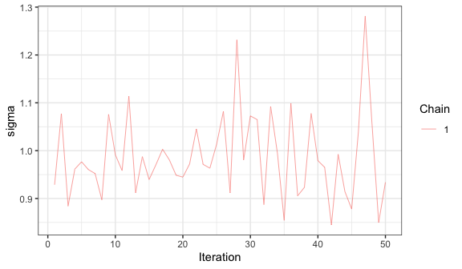

```r
plot(fit_hs, type = "trace")
```

#### Posterior ATE distribution (causal models)

[figure not shown]

```r
plot(fit_chf, type = "ate")
```

#### CATE caterpillar plot

[figure not shown]

```r
plot(fit_chf, type = "cate")
```

#### Variable importance (Dirichlet prior)

Variable importance plots are available when `prior_type = "dirichlet"`. For causal models with `prior_type_control = "dirichlet"` or `prior_type_treat = "dirichlet"`, use `forest = "control"`, `"treat"`, or `"both"`.

```r
set.seed(12)
fit_dart <- ShrinkageTrees(
  y               = y_cont,
  X_train         = X_syn,
  outcome_type    = "continuous",
  prior_type      = "dirichlet",
  local_hp        = 0.1 / sqrt(5),
  number_of_trees = 5,
  N_post          = 50,
  N_burn          = 25,
  verbose         = FALSE
)
```

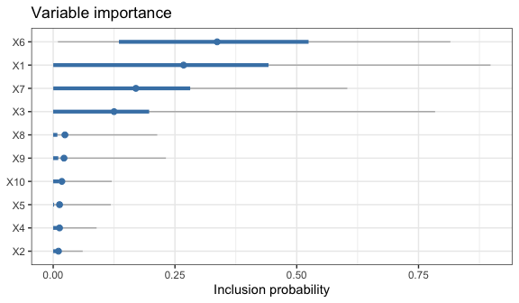

```r
plot(fit_dart, type = "vi", n_vi = 10)
```

#### Survival curves

For survival models (`outcome_type = "right-censored"` or `"interval-censored"`), the `plot()` method can draw posterior survival curves derived from the fitted AFT log-normal model:
$$S(t \mid \mathbf{x}_i) = 1 - \Phi\!\left(\frac{\log t -
\mu_i}{\sigma}\right),$$
where $\mu_i = f(\mathbf{x}_i)$ is the BART ensemble prediction and $\sigma$ is the residual standard deviation on the log-time scale.

The `type = "survival"` option supports two modes controlled by the `obs` argument:

- **Population-averaged curve** (`obs = NULL`, the default): computes $\bar{S}(t) = n^{-1}\sum_i S(t \mid \mathbf{x}_i)$ at each MCMC iteration, giving credible bands that reflect full posterior uncertainty.
- **Individual curves** (`obs = c(1, 5, ...)`): one curve per selected training observation with its own credible band.

Additional options:

| Argument | Description |
| --- | --- |
| `level` | Width of the pointwise credible band (default `0.95`). |
| `t_grid` | Custom time grid (original scale). Auto-generated if `NULL`. |
| `km` | If `TRUE`, overlay the Kaplan–Meier estimate (population-average only). |

We use the survival fit from the earlier section:

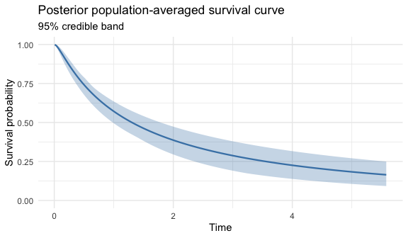

```r
# Population-averaged survival curve with 95% credible band
plot(ht_surv, type = "survival")
```

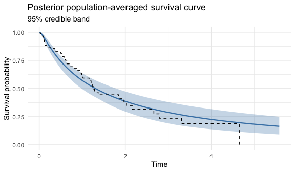

```r
# Same curve with the Kaplan-Meier estimate overlaid for comparison
plot(ht_surv, type = "survival", km = TRUE)
```

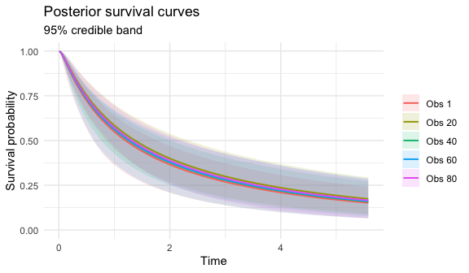

```r
# Individual survival curves for observations 1, 20, 40, 60, and 80
plot(ht_surv, type = "survival", obs = c(1, 20, 40, 60, 80))
```

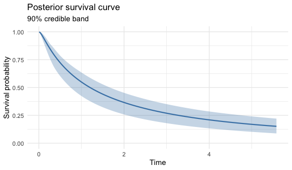

```r
# Single individual with a narrower 90% credible band
plot(ht_surv, type = "survival", obs = 1, level = 0.90)
```

When `store_posterior_sample = FALSE`, the credible bands only reflect uncertainty in $\sigma$ (using plug-in posterior mean $\hat{\mu}_i$). The survival functions (`SurvivalBART`, `SurvivalDART`, etc.) store posterior samples by default, so full posterior bands are available out of the box.

#### Posterior predictive survival curves

The survival curves above are based on the **training** data — they show $S(t \mid \mathbf{x}_i)$ for the observations used to fit the model. For **new** (out-of-sample) data, call `predict()` first and then `plot()` on the prediction object. This produces *posterior predictive* survival curves that propagate full parameter uncertainty through to the new covariate values:

```r
# New observations for prediction
set.seed(99)
X_new <- matrix(rnorm(20 * p), ncol = p)
pred_surv <- predict(ht_surv, newdata = X_new)
```

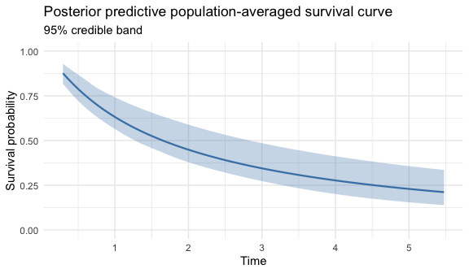

```r
# Population-averaged posterior predictive survival curve
plot(pred_surv, type = "survival")
```

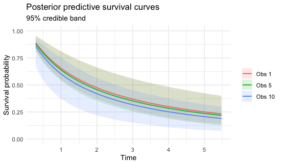

```r
# Individual posterior predictive curves for selected new observations
plot(pred_surv, type = "survival", obs = c(1, 5, 10))
```

The same `level` and `t_grid` arguments are available as for the training-data survival curves. The Kaplan–Meier overlay (`km = TRUE`) is not available for prediction objects, since observed event times are only known for the training set.

## Multi-Chain MCMC

Running multiple independent chains improves mixing diagnostics and reduces sensitivity to starting values. Pass `n_chains > 1` to any model-fitting function; chains are run in parallel via `parallel::mclapply` on Unix-like systems.

```r
set.seed(13)
fit_2chain <- ShrinkageTrees(
  y               = y_cont,
  X_train         = X_syn,
  outcome_type    = "continuous",
  prior_type      = "horseshoe",
  local_hp        = 0.1 / sqrt(5),
  global_hp       = 0.1 / sqrt(5),
  number_of_trees = 5,
  N_post          = 50,
  N_burn          = 25,
  n_chains        = 2,
  verbose         = FALSE
)

cat("n_chains stored  :", fit_2chain$mcmc$n_chains, "\n")
```

```
#> n_chains stored  : 2
```

```r
cat("Total sigma draws:", length(fit_2chain$sigma),
    " (2 chains x 50 draws)\n")
```

```
#> Total sigma draws: 100  (2 chains x 50 draws)
```

```r
cat("Per-chain acceptance ratios:\n")
```

```
#> Per-chain acceptance ratios:
```

```r
print(round(fit_2chain$chains$acceptance_ratios, 3))
```

```
#> [1] 0.496 0.472
```

The same interface works for causal models.

```r
set.seed(14)
fit_causal_2chain <- CausalShrinkageForest(
  y                         = y_causal,
  X_train_control           = X_syn,
  X_train_treat             = X_syn,
  treatment_indicator_train = W_syn,
  outcome_type              = "continuous",
  prior_type_control        = "horseshoe",
  prior_type_treat          = "horseshoe",
  local_hp_control          = lh,
  global_hp_control         = lh,
  local_hp_treat            = lh,
  global_hp_treat           = lh,
  number_of_trees_control   = 5,
  number_of_trees_treat     = 5,
  N_post                    = 50,
  N_burn                    = 25,
  n_chains                  = 2,
  verbose                   = FALSE
)

cat("Pooled sigma draws:", length(fit_causal_2chain$sigma), "\n")
```

```
#> Pooled sigma draws: 100
```

```r
cat("Per-chain acceptance ratios (control):\n")
```

```
#> Per-chain acceptance ratios (control):
```

```r
print(round(fit_causal_2chain$chains$acceptance_ratios_control, 3))
```

```
#> [1] 0.36 0.36
```

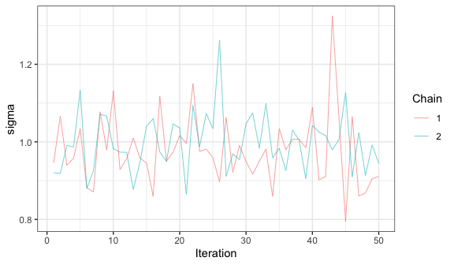

```r
plot(fit_2chain, type = "trace")
```

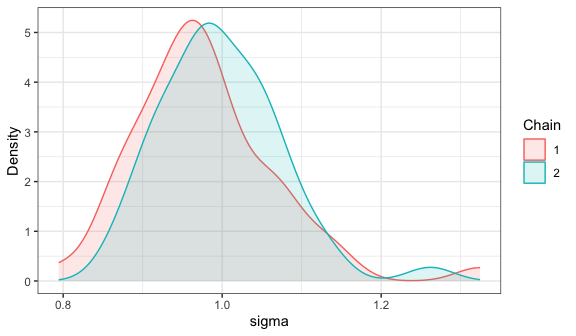

```r
plot(fit_2chain, type = "density")
```

## Convergence Diagnostics

MCMC methods require careful assessment of convergence before trusting the posterior summaries. Here are practical guidelines for **ShrinkageTrees** models.

### Sigma traceplot

The traceplot of the error standard deviation $\sigma$ (via `plot(fit, type = "trace")`) is the primary diagnostic. A well-mixing chain should show:

- **No trend**: the trace should fluctuate around a stable level after burn-in. A persistent upward or downward drift indicates the sampler has not yet converged — increase `N_burn`.
- **Good mixing**: the chain should move freely across its stationary range. If the trace is “sticky” (stays in the same region for long stretches), this indicates poor mixing.
- **Chain agreement** (when `n_chains > 1`): separate chains should overlap substantially. The density overlay (`plot(fit, type = "density")`) makes this easy to check visually.

### Acceptance ratio

The `summary()` output reports the average Metropolis–Hastings acceptance ratio for the tree structure proposals (grow/prune moves). As a rough guide:

- **0.15–0.50** is typical and healthy for tree-based MCMC.
- **Very low** (< 0.05) means most proposals are rejected. The sampler is barely exploring tree space. Consider increasing `N_burn` and `N_post`, or relaxing the tree structure prior (lower `power`, higher `base`).
- **Very high** (> 0.70) means almost all proposals are accepted, which typically indicates the trees are staying very small (e.g. stumps). This is less concerning but may limit the model’s expressiveness.

### Formal diagnostics with coda

When the suggested package **coda** is installed, `summary()` automatically reports **effective sample size** (ESS) and — for multi-chain fits — the **Gelman–Rubin $\hat{R}$**.

```r
# summary() includes convergence diagnostics when coda is available
summary(fit_2chain)
```

```
#>
#> ShrinkageTrees model summary
#> ============================
#> Call: ShrinkageTrees(y = y_cont, X_train = X_syn, outcome_type = "continuous",
#>     number_of_trees = 5, prior_type = "horseshoe", local_hp = 0.1/sqrt(5),
#>     global_hp = 0.1/sqrt(5), N_post = 50, N_burn = 25, n_chains = 2,
#>     verbose = FALSE)
#>
#> Outcome: Continuous | Prior: horseshoe | Trees: 5
#> Data:    n = 80, p = 10 | Draws: 50 x 2 chains (burn-in 25)
#>
#> Posterior sigma:
#>   Mean: 0.988  SD: 0.084  95% CI: [0.86, 1.142]
#>
#> Predictions (posterior mean):
#>   Train: mean = 0.051, sd = 0.023, range = [-0.008, 0.101]
#>   Test:  mean = 0.047, sd = NA, range = [0.047, 0.047]
#>
#> Variable importance (posterior inclusion probability):
#>   X2: 0.132   X9: 0.129   X3: 0.126   X7: 0.123   X5: 0.114   X10: 0.101   X8: 0.096   X4: 0.09   X6: 0.052   X1: 0.037
#>
#> MCMC acceptance ratio (per chain): 0.496, 0.472
#>
#> Convergence diagnostics (coda):
#>   Gelman-Rubin R-hat:  = 1.029
#>   Effective sample size: sigma = 100
```

For more detailed diagnostics, convert the fitted object to a `coda::mcmc.list` with `as.mcmc.list()`:

```r
library(coda)
mcmc_obj <- as.mcmc.list(fit_2chain)

# Gelman-Rubin R-hat (values near 1 indicate convergence)
coda::gelman.diag(mcmc_obj)
```

```
#> Potential scale reduction factors:
#>
#>       Point est. Upper C.I.
#> sigma       1.07       1.28
```

```r
# Effective sample size
coda::effectiveSize(mcmc_obj)
```

```
#> sigma
#>   100
```

```r
# Geweke diagnostic (per chain)
coda::geweke.diag(mcmc_obj[[1]])
```

```
#>
#> Fraction in 1st window = 0.1
#> Fraction in 2nd window = 0.5
#>
#>   sigma
#> 0.05444
```

The returned `mcmc.list` object is compatible with all **coda** functions, including `coda::autocorr.plot()`, `coda::gelman.plot()`, `coda::heidel.diag()`, and `coda::raftery.diag()`.

### Recommended MCMC settings

The examples in this vignette use very small `N_post` and `N_burn` to keep build time low. For a real analysis:

- **Minimum**: `N_post = 2000, N_burn = 2000`.
- **Recommended**: `N_post = 5000, N_burn = 5000`.
- **High-dimensional or survival**: `N_post = 5000, N_burn = 10000` (the AFT data augmentation step can slow mixing, so a longer burn-in helps).
- **Multiple chains**: `n_chains = 2` or `4` to verify convergence and produce pooled posterior samples.

## Case Study: TCGA PAAD (Full Analysis)

The full analysis of the `pdac` dataset replicates the case study from Jacobs, van Wieringen & van der Pas (2025). Due to the high-dimensional covariate space (~3,000 genes) and the large MCMC settings needed for reliable inference, the code below is provided for reference but is not evaluated during vignette building. Pre-computed results can be reproduced by running the `pdac_analysis` demo: `demo("pdac_analysis", package = "ShrinkageTrees")`.

### Step 1: Propensity score estimation

```r
data("pdac")

time      <- pdac$time
status    <- pdac$status
treatment <- pdac$treatment
X         <- as.matrix(pdac[, !(names(pdac) %in% c("time","status","treatment"))])

set.seed(2025)
ps_fit <- HorseTrees(
  y            = treatment,
  X_train      = X,
  outcome_type = "binary",
  k            = 0.1,
  N_post       = 5000,
  N_burn       = 5000,
  verbose      = FALSE
)

propensity <- pnorm(ps_fit$train_predictions)
```

```r
# Overlap plot
p0 <- propensity[treatment == 0]
p1 <- propensity[treatment == 1]

hist(p0, breaks = 15, col = rgb(1, 0.5, 0, 0.5), xlim = range(propensity),
     xlab = "Propensity score", main = "Propensity score overlap")
hist(p1, breaks = 15, col = rgb(0, 0.5, 0, 0.5), add = TRUE)
legend("topright", legend = c("Control", "Treated"),
       fill = c(rgb(1,0.5,0,0.5), rgb(0,0.5,0,0.5)))
```

### Step 2: Causal survival forest

```r
# Augment control matrix with propensity scores (BCF-style)
X_control <- cbind(propensity, X)

# Log-transform and centre survival times
log_time <- log(time) - mean(log(time))

set.seed(2025)
fit_pdac <- CausalHorseForest(
  y                         = log_time,
  status                    = status,
  X_train_control           = X_control,
  X_train_treat             = X,
  treatment_indicator_train = treatment,
  outcome_type              = "right-censored",
  timescale                 = "log",
  number_of_trees           = 200,
  N_post                    = 5000,
  N_burn                    = 5000,
  store_posterior_sample    = TRUE,
  verbose                   = FALSE
)
```

### Step 3: ATE and CATE estimation

```r
# Print model summary
print(fit_pdac)
smry_pdac <- summary(fit_pdac)
print(smry_pdac)

# ATE
cat("ATE posterior mean:",
    round(smry_pdac$treatment_effect$ate, 3), "\n")
cat("95% CI: [",
    round(smry_pdac$treatment_effect$ate_lower, 3), ",",
    round(smry_pdac$treatment_effect$ate_upper, 3), "]\n")
```

### Step 4: Diagnostics

```r
# Sigma convergence
plot(fit_pdac, type = "trace")

# Posterior ATE density
plot(fit_pdac, type = "ate")

# CATE caterpillar plot
plot(fit_pdac, type = "cate")
```

## References

Chipman, H. A., George, E. I., & McCulloch, R. E. (2010). Bayesian Additive Regression Trees. *Annals of Applied Statistics*, 4(1), 266–298.

Hahn, P. R., Murray, J. S., & Carvalho, C. M. (2020). Bayesian Regression Tree Models for Causal Inference: Regularization, Confounding, and Heterogeneous Treatment Effects. *Bayesian Analysis*, 15(3), 965–1056.

Jacobs, T., van Wieringen, W. N., & van der Pas, S. L. (2025). Horseshoe Forests for High-Dimensional Causal Survival Analysis. *arXiv preprint* arXiv:2507.22004.

Linero, A. R. (2018). Bayesian Regression Trees for High-Dimensional Prediction and Variable Selection. *Journal of the American Statistical Association*, 113(522), 626–636.

Sparapani, R., Spanbauer, C., & McCulloch, R. (2021). Nonparametric Machine Learning and Efficient Computation with Bayesian Additive Regression Trees: The BART R Package. *Journal of Statistical Software*, 97(1), 1–66.